# *Layoffs and the AI Era: An Analysis of Structural Shifts in the Tech Labor Market*

Pablo Sokolic. Data Analyst.

June 20, 2025

We’ve all seen the headlines over the past few years: Amazon, Google, Microsoft—one by one, tech giants have announced layoffs in the hundreds, even thousands. But what’s driving this wave of job cuts?

The **surge of artificial intelligence in late 2022** coincided with sweeping restructurings across the industry. Was it just timing— or did the AI boom accelerate a shift already in motion?

Of course, **broader economic forces may also be at play**. Rising interest rates, inflation, stagnant GDP, recession fears—all of these could be shaping the labor dynamics unfolding before us.

In this report, we’ll take a closer look at what’s been happening in the IT labor market since 2020 and explore the interplay between tech innovation and economic volatility.

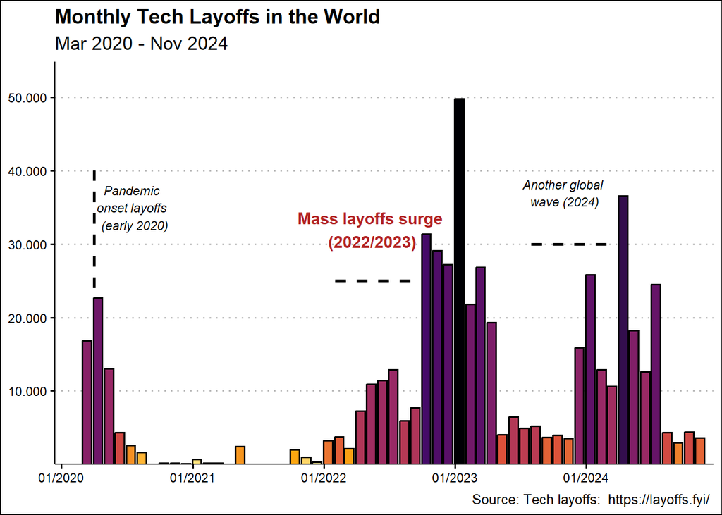

```r
library(readr)
library(tidyverse)
library(ggthemes)
library(viridis)
library(ggrepel)
library(scales)
library(patchwork)
library(lubridate)

 #importing tech layoffs
 tech_layoffs <- read_delim("tech_layoffs/tech_layoffs_til_Q4_2024.csv",
                            delim = ";", escape_double = FALSE, trim_ws = TRUE)

 #View(tech_layoffs)

 #dealing with date formats
 tech_layoffs$Date_layoffs <- dmy(tech_layoffs$Date_layoffs)

 tech_layoffs$Month <- month(tech_layoffs$Date_layoffs)
 tech_layoffs$Year <- year(tech_layoffs$Year)

 #glimpse(tech_layoffs)

 #create monthly breaks of the dates
 monthly_breaks <-  seq.Date(from = min(tech_layoffs$Date_layoffs),
                             to = max(tech_layoffs$Date_layoffs), by = "month")

 #group date in monthly intervals
 #cut converts a variable (num or date) into categories based on intervals
 tech_layoffs$year_month <- cut(tech_layoffs$Date_layoffs,
                                breaks = monthly_breaks)
 #glimpse(tech_layoffs)

 # Aggregate layoffs per month for all countries
 tech_layoffs_summary <- tech_layoffs %>%
   group_by(year_month) %>%
   summarize(total_laid_off = sum(Laid_Off, na.rm = TRUE))

 #tech_layoffs_summary <- tech_layoffs_summary %>%
 # mutate(year_month = floor_date(year_month, "month"))


# Convert year_month to Date format for plotting
tech_layoffs_summary$year_month <- as.Date(tech_layoffs_summary$year_month)

#glimpse(tech_layoffs_summary)

#plotting layoffs in all countries
plot_layoffs_all <- tech_layoffs_summary %>%
  ggplot(aes(year_month, total_laid_off, fill = total_laid_off)) +
  geom_col(linewidth = 0.7, colour = "black") +
  theme_clean() +
  labs(title = "Monthly Tech Layoffs in the World",
       subtitle = "Mar 2020 - Nov 2024",
       caption = "Source: Tech layoffs:  https://layoffs.fyi/ ",
       x = NULL,
       y = NULL) +
  scale_fill_viridis_c(option = "inferno", direction = -1, name = "Layoffs",
                       values = c(0, 0.1, 1), guide = "none") +
  scale_y_continuous(labels = label_number(big.mark = ".", decimal.mark = ","),
                     expand = c(0,0.05), breaks = seq(10000, 60000, 10000),
                     limits = c(0, max(tech_layoffs_summary$total_laid_off) +5000)) +
  scale_x_date(labels = label_date(format = "%m/%Y"),
               date_breaks = "1 year", expand = c(0.01,0),
               limits = as.Date(c('2020-01-01', '2024-12-01'))) +
  annotate("text", x = as.Date("2020-07-20"), y = 35000,
           label = "Pandemic \nonset layoffs \n (early 2020)", size = 3, fontface = "italic") +
  geom_segment(x = as.Date("2020-04-01"),
               linetype = "dashed", colour = "black",
               linewidth = 1, y = 24000, yend = 40000) +
  annotate("text", x = as.Date("2022-05-15"), y = 32000,
           label = "Mass layoffs surge \n(2022/2023)", size = 4, fontface = "bold",
           color = "firebrick") +
  geom_segment(y = 25000,
               linetype = "dashed", colour = "black",
               linewidth = 1, x = as.Date("2022-02-01"), xend = as.Date("2022-9-01")) +
  annotate("text", x = as.Date("2023-11-01"), y = 37000,
           label = "Another global \nwave (2024)", size = 3, fontface = "italic") +
  geom_segment(y = 30000,
               linetype = "dashed", colour = "black",
               linewidth = 1, x = as.Date("2023-08-01"), xend = as.Date("2024-3-01"))


plot_layoffs_all
```

We can identify **three distinct waves of layoffs in the tech industry**: the first during the onset of the COVID-19 pandemic in early 2020; the second between late 2022 and early 2023—coinciding with the public debut of ChatGPT on November 30, 2022; and the third unfolding in the first half of 2024

There’s something interesting in this graph: *the absence of layoffs between July 2020 and early 2022*. That’s the **period marked by aggressive hiring** across the IT sector.

Now, when we compare these trends across the United States and the rest of the world, a striking pattern emerges: **the timing and intensity of layoffs are remarkably synchronized**, suggesting that global forces—rather than region-specific shocks— may be driving these shifts:

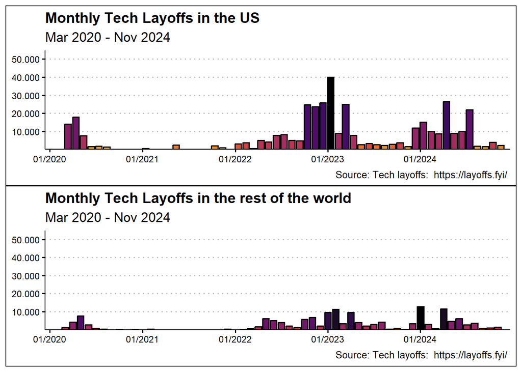

```r
library(readr)

 # Aggregate layoffs per month for the US
 tech_layoffs_us_summary <- tech_layoffs %>%
   filter(Country == "USA") %>%
   group_by(year_month) %>%
   summarize(total_laid_off = sum(Laid_Off, na.rm = TRUE))

 #tech_layoffs_us_summary <- tech_layoffs_us_summary %>%
  # mutate(year_month = floor_date(year_month, "month"))

#glimpse(tech_layoffs_us_summary)
#summary(tech_layoffs_us_summary)

# Convert year_month to Date format for plotting
tech_layoffs_us_summary$year_month <- as.Date(tech_layoffs_us_summary$year_month)

#glimpse(tech_layoffs_world_summary)

#plotting layaff in the US
plot_layoffs_us <- tech_layoffs_us_summary %>%
  ggplot(aes(year_month, total_laid_off, fill = total_laid_off)) +
  geom_col(linewidth = 0.7, colour = "black") +
  theme_clean() +
  labs(title = "Monthly Tech Layoffs in the US",
       subtitle = "Mar 2020 - Nov 2024",
       caption = "Source: Tech layoffs:  https://layoffs.fyi/ ",
       x = NULL,
       y = NULL) +
  scale_fill_viridis_c(option = "inferno", direction = -1, name = "Layoffs",
                       values = c(0, 0.1, 1), guide = "none") +
  scale_y_continuous(labels = label_number(big.mark = "."),
                     expand = c(0,0), breaks = seq(10000, 60000, 10000),
                     limits = c(0, max(tech_layoffs_summary$total_laid_off) +5000) ) +
  scale_x_date(labels = label_date(format = "%m/%Y"),
               date_breaks = "1 year", expand = c(0.01,0),
               limits = as.Date(c('2020-01-01', '2024-12-01')))



 # Aggregate layoffs per month for the rest of the world
library(stringr)

tech_layoffs_non_us_summary <- tech_layoffs %>%
  filter(!str_detect(Country, regex("usa|united states", ignore_case = TRUE))) %>%
  filter(!is.na(Laid_Off)) %>%
  mutate(year_month = floor_date(as.Date(Date_layoffs), "month")) %>%
  group_by(year_month) %>%
  summarise(total_laid_off = sum(Laid_Off)) %>%
  complete(year_month = seq.Date(from = as.Date("2020-03-01"),
                                 to = as.Date("2024-12-01"),
                                 by = "month"),
           fill = list(total_laid_off = 0))

#glimpse(tech_layoffs_non_us_summary)
#sum(tech_layoffs_non_us_summary$total_laid_off)

 # Convert year_month to Date format for plotting
  #tech_layoffs_world_summary$year_month <- as.Date(tech_layoffs_world_summary$year_month)

 #glimpse(tech_layoffs_world_summary)
 #summary(tech_layoffs_world_summary)

#plotting layoffs in the rest of the world
plot_layoffs_world <- tech_layoffs_non_us_summary %>%
     ggplot(aes(year_month, total_laid_off, fill = total_laid_off)) +
     geom_col(linewidth = 0.7, colour = "black") +
     theme_clean() +
     labs(title = "Monthly Tech Layoffs in the rest of the world",
          subtitle = "Mar 2020 - Nov 2024",
          caption = "Source: Tech layoffs:  https://layoffs.fyi/ ",
          x = NULL,
          y = NULL) +
     scale_fill_viridis_c(option = "inferno", direction = -1, name = "Layoffs",
                          values = c(0, 0.1, 1), guide = "none") +
     scale_y_continuous(labels = label_number(big.mark = "."),
                        expand = c(0,0), breaks = seq(10000, 60000, 10000),
                        limits = c(0, max(tech_layoffs_summary$total_laid_off) +5000)) +
     scale_x_date(labels = label_date(format = "%m/%Y"),
                  date_breaks = "1 year", expand = c(0.01,0),
                  limits = as.Date(c('2020-01-01', '2024-12-01')))



#plotting layoffs in the US and the rest of the world
    plot_layoffs_us / plot_layoffs_world
```

We could analyze which companies had the biggest layoffs between 2020 and 2024:

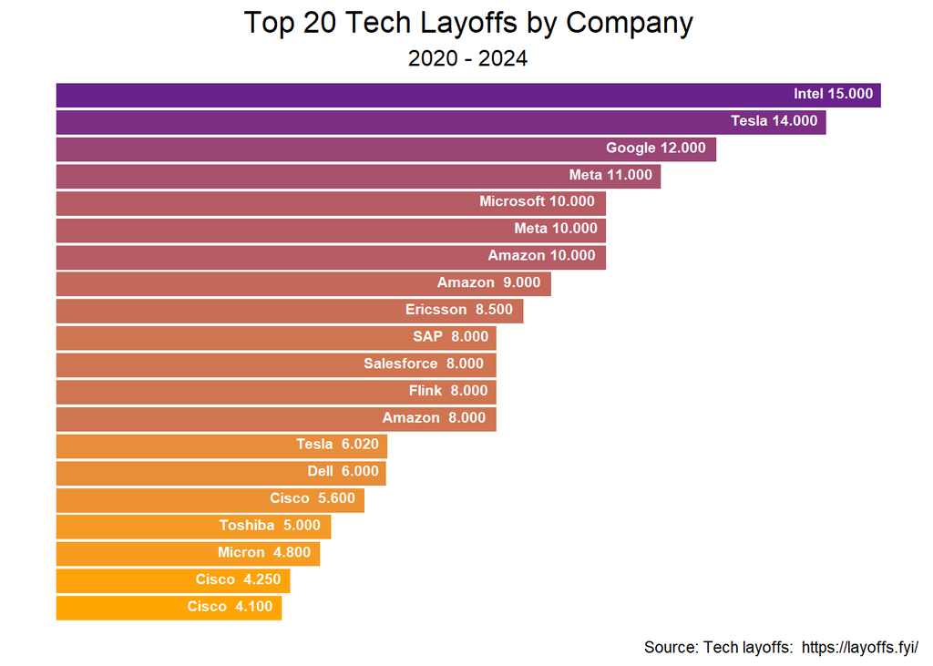

```r
#changing the name of a company due to error
tech_layoffs$Company <- gsub("SaleSan Francisco Bay Areaorce", "Salesforce", tech_layoffs$Company)

#layoffs by month and company
tech_layoff_by_company <- tech_layoffs %>%
  select(year_month, Laid_Off, Company) %>%
  arrange(desc(Laid_Off)) %>%
  mutate(rank = row_number()) %>%
  filter(rank <= 20) %>%
  select(-rank)

top_20_cleaned <- tech_layoff_by_company %>%
  arrange(desc(Laid_Off)) %>%
  slice_head(n = 20)  # Select 20 biggest layoffs

top_20_cleaned <- top_20_cleaned %>%
  arrange(desc(Laid_Off))

#top_20_cleaned %>% count(Company) %>% arrange(desc(n))

top_20_cleaned <- top_20_cleaned %>%
  mutate(year_month = case_when(
    Company == "Tesla" & Laid_Off == 6020 ~ "2024-04-24",  # New date for this row
    TRUE ~ as.character(year_month)))  # Keeps the rest unchanged

#str(top_20_cleaned)
#nrow(top_20_cleaned)


#plotting the 20 biggest layoffs between 2020-2024
ggplot(top_20_cleaned,
       aes(x= reorder(paste(Company, year_month), Laid_Off), y= Laid_Off),
       fill = as.factor(year_month), size = Laid_Off) +
  geom_col(aes(fill = Laid_Off), width = 0.9) +
  geom_text(aes(label = paste0(Company, " ", format(Laid_Off, big.mark = "."))),
            hjust = 1.1, vjust = 0.2, colour = "gray100", size = 2.8, fontface = "bold") +
  guides(fill = "none") +
  coord_flip() +
  theme_classic() +
  labs(title = "Top 20 Tech Layoffs by Company",
       subtitle = "2020 - 2024",
       x = NULL,
       y = NULL,
       caption = "Source: Tech layoffs:  https://layoffs.fyi/ ") +
  theme(axis.text.x = element_blank(),
        axis.text.y = element_blank(),
        axis.ticks = element_blank(),
        axis.line = element_blank()) +
  scale_fill_gradient(low = "orange1", high = "darkorchid4") +
  theme(plot.title = element_text(hjust = 0.5, size = 16),
        plot.subtitle = element_text(hjust = 0.5, size = 12))
```

Looking at the comparative graphs of layoffs in the US versus the rest of the world, we notice *significantly more layoffs in the US*—or at least among American companies. Let’s now examine the proportions to better understand the distribution:

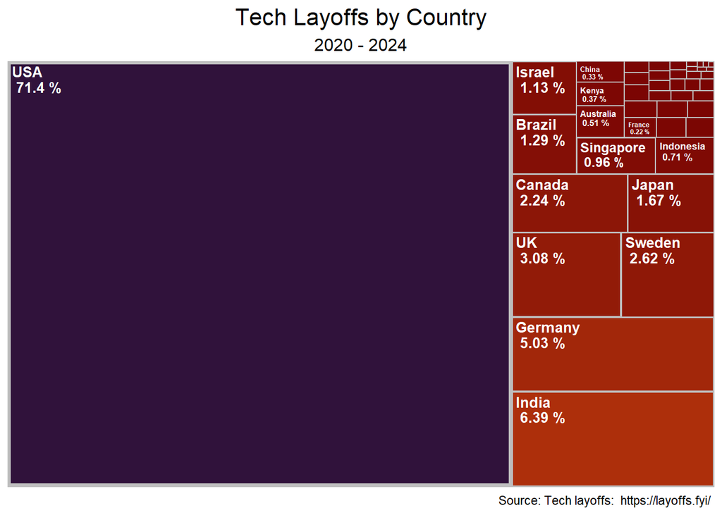

```r
library(treemapify)

#layoffs by country
tech_summary <- tech_layoffs %>%
  select(Country, Laid_Off) %>%
  filter(!is.na(Country )) %>%
  group_by(Country) %>%
  summarize(Laid_offs = sum(Laid_Off, na.rm = TRUE)) %>%
  mutate(perc_layoffs = round((Laid_offs/sum(Laid_offs))*100, 2)) %>%
  arrange(desc(Laid_offs), desc(perc_layoffs))

#glimpse(tech_summary)

tech_summary %>% ggplot() +
  geom_treemap(aes(area = Laid_offs, fill = Laid_offs,
                   label = paste(Country, "\n", perc_layoffs, "%"),
                   size = Laid_offs)) +
  geom_treemap_text(aes(area = Laid_offs,
                        label = paste(Country, "\n", perc_layoffs, "%")),
                    fontface = "bold", color = "white", size = 10) +
  scale_fill_viridis_c(option = "turbo", direction = -1,
                       guide = "none") +
  theme_minimal() +
  labs(title = "Tech Layoffs by Country",
       subtitle = "2020 - 2024",
       fill = "Total Laid Off",
       caption = "Source: Tech layoffs:  https://layoffs.fyi/ ") +
  guides(size = "none") +
  theme(plot.title = element_text(hjust = 0.5, size = 16),
        plot.subtitle = element_text(hjust = 0.5, size = 12))
```

Now let’s turn to some time series graphs that highlight key trends in U.S. financial indicators—such as inflation, GDP growth, and interest rates.

But first, we’ll start with a closer look at the stock prices of major Big Tech companies (Amazon, Google, Microsoft, Apple, and Meta) from 2020 to 2024. This will provide a baseline for how these industry giants navigated the shifting economic landscape over the past few years.

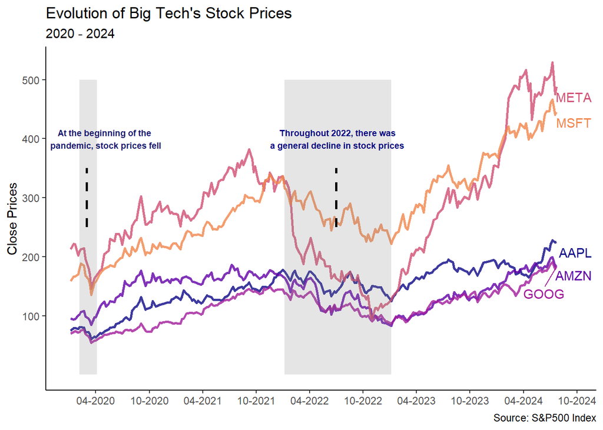

```r
#importing stock markets data
all_stocks <- read_csv("all_stocks.csv")
#View(all_stocks)

all_stocks$date <- as.Date(all_stocks$date, format = "%Y-%m-%d")

#glimpse(all_stocks)
#glimpse(all_stocks$Name)

all_stocks$Name <- as.factor(all_stocks$Name)

labels_stocks <- all_stocks %>%
  filter(Name %in% c("AMZN", "GOOG", "META", "MSFT", "AAPL")) %>%
  filter(date == max(date)) %>%
  select(date, Name, close)

#glimpse(labels_stocks)

big_tech_stocks <- all_stocks %>%
  filter(Name %in% c("AMZN", "GOOG", "META", "MSFT", "AAPL")) %>%
  ggplot(aes(date, close, colour = Name)) +
  #geom_smooth(method = "loess", linewidth = 0.8, colour = "red") +
  geom_line(aes(colour = Name), linewidth = 1.05, alpha = 0.8) +
  theme_classic() +
  annotate(geom = "rect", xmin = ymd("2022-01-05"), xmax = ymd("2023-01-05"),
           ymin = 0, ymax = 500,
           fill = "grey50", alpha = 0.2) +
  annotate(geom = "rect", xmin = ymd("2020-02-05"), xmax = ymd("2020-04-05"),
           ymin = 0, ymax = 500,
           fill = "grey50", color = NA, alpha = 0.2) +
  geom_segment(x = as.Date("2020-03-01"),
             linetype = "dashed", colour = "black",
             linewidth = 1, y = 250, yend = 350) +
  geom_segment(x = as.Date("2022-07-01"),
               linetype = "dashed", colour = "black",
               linewidth = 1, y = 250, yend = 350) +
  annotate(geom = "text", label = "At the beginning of the \npandemic, stock prices fell",
           x = ymd("2020-05-05"), y = 400, size = 2.5, fontface = "bold",
           colour = "midnightblue") +
  annotate(geom = "text", label = "Throughout 2022, there was\na general decline in stock prices",
           x = ymd("2022-07-05"), y = 400, size = 2.5, fontface = "bold",
           colour = "navyblue") +
  geom_text_repel(data = labels_stocks,
                  aes(x = date, y = close, label = Name), nudge_x = 50, vjust =0) +
  labs(title = "Evolution of Big Tech's Stock Prices",
       subtitle = "2020 - 2024",
       caption = "Source: S&P500 Index",
       x = NULL,
       y = "Close Prices") +
 guides(colour = "none") +
  scale_x_date(date_breaks = "6 months", date_labels = "%m-%Y") +
  scale_colour_viridis_d(option = "plasma", end = 0.7) +
  scale_y_continuous(breaks = seq(100, 500, 100))


big_tech_stocks
```

Stock prices saw **notable declines** during two key periods: the onset of the COVID-19 pandemic in early 2020, and again in 2022. If we revisit the earlier layoffs graph, **these downturns seem to align with spikes in job cuts** —raising the possibility of a connection between market performance and workforce reductions. Could layoffs be a reaction to falling stock prices, or are both symptoms of deeper economic shifts?

Let’s now explore how other key financial indicators—such as inflation, GDP growth, and interest rates—evolved during this same period:

```r
library(dygraphs)
library(readr)
library(xts)
library(TSstudio)

financial_indicators <- read_csv("main.csv")
#View(financial_indicators)

#glimpse(financial_indicators)

financial_index <- financial_indicators %>%
  mutate(Date = as.Date(date)) %>%
  filter(Date >= as.Date("2020-03-01"))

#create time series objects and plot them using zoo or xts
financial_index_xts <- xts(x = financial_index[,c("Interest_Rate", "Inflation",
                                                  "GDP", "Unemployment", "Ind_Prod",
                                                  "sp500")],
                           frequency = 12,
                           order.by = as.Date(financial_index$date))

#class(financial_index_xts)
#ts_info(financial_index_xts)

#glimpse(financial_index)

#using dygraphs to create line graphs
dygraph(financial_index_xts[, "Interest_Rate"], main = "Interest Rate (%)",
        width = "100%", height = 250) %>%
  dyOptions(colors = "darkblue", strokeWidth = 2) %>%
  dyRangeSelector()
```

[interactive chart not shown]

```r
dygraph(financial_index_xts[, "sp500"], main = "S&P 500 Index",
        width = "100%", height = 250) %>%
  dyOptions(colors = "forestgreen", strokeWidth = 2) %>%
  dyRangeSelector()
```

[interactive chart not shown]

```r
dygraph(financial_index_xts[, "Inflation"], main = "Inflation",
        width = "100%", height = 250) %>%
  dyOptions(colors = "firebrick", strokeWidth = 2) %>%
  dyRangeSelector()
```

[interactive chart not shown]

```r
dygraph(financial_index_xts[, "Unemployment"], main = "Unemployment (%)",
        width = "100%", height = 250) %>%
  dyOptions(colors = "tomato", strokeWidth = 2) %>%
  dyRangeSelector()
```

[interactive chart not shown]

```r
dygraph(financial_index_xts[, "GDP"], main = "GDP",
        width = "100%", height = 250) %>%
  dyOptions(colors = "steelblue4", strokeWidth = 2) %>%
  dyRangeSelector()
```

[interactive chart not shown]

*Source: U.S. Federal Reserve Economic Data (FRED)*

From these financial indicators, several key patterns emerge:

- **Interest Rates**: Beginning in early 2022, we observe a steep and sustained rise in U.S. interest rates—from just 0.08% in February 2022 to 5.33% by August 2023. This marks one of the most aggressive tightening cycles in recent decades.
- **Inflation**: Inflation began climbing steadily around July 2020, fueled by post-pandemic supply chain pressures and fiscal stimulus. It remained elevated throughout much of the period under review. *Note: The inflation data shown here represents index values, not percentage changes.
- **S&P 500**: The index mirrors the stock price trajectory of Big Tech firms, with a sharp decline during 2022, suggesting broad market stress likely tied to macroeconomic shifts and monetary policy adjustments.
- **Unemployment**: The labor market experienced a pronounced spike in unemployment at the start of the pandemic, followed by a rapid recovery. However, beginning in 2023, a more gradual uptick appears—hinting at potential cooling in labor demand.
- **GDP**: While U.S. GDP contracted sharply in 2020, the economy rebounded relatively quickly. This resilience underscores the strength of U.S. fundamentals, even amid inflationary and monetary headwinds.

Conclusion: *This analysis has highlighted the timing, magnitude, and possible drivers behind recent waves of tech layoffs. But while descriptive trends help us see the “what” and the “when,” they don’t fully answer the “why.”* In a second part of this report, I’ll try to develop a statistical model to explore which factors may have had the greatest influence on layoffs between 2020 and 2024.